# File S1

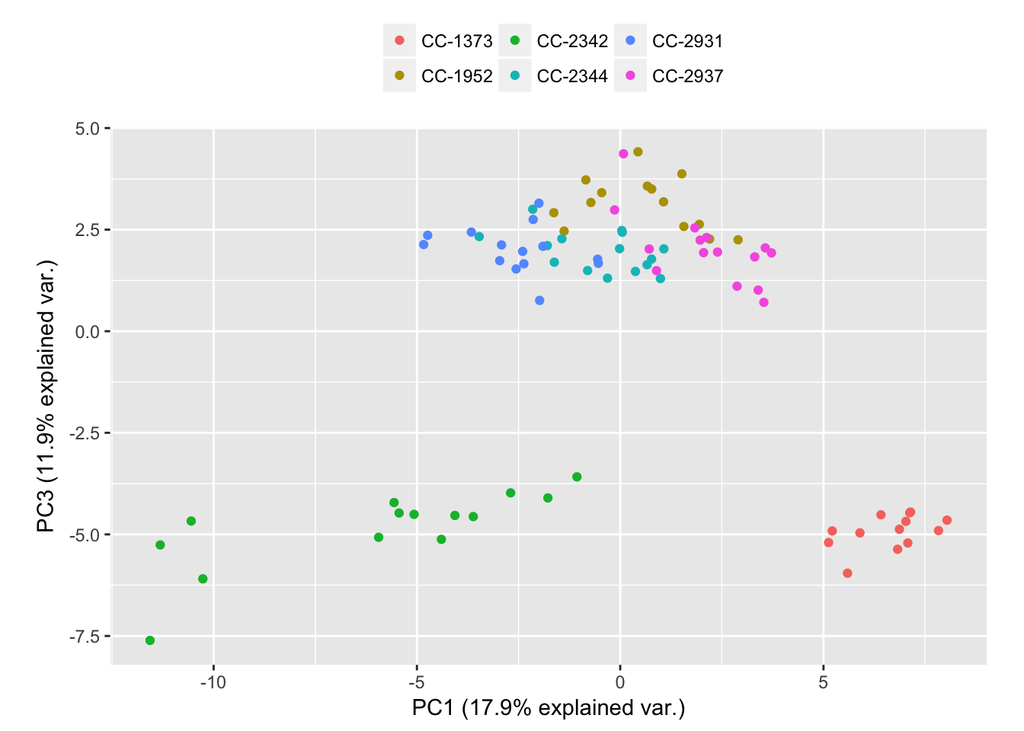

```r
g <- ggbiplot(pca.data, obs.scale = 1, var.scale = 1, groups = category, var.axes = F, choices=c(1,3))
g <- g + scale_color_discrete(name='')
g <- g + theme(legend.direction='horizontal', legend.position='top')
print(g)
```

# Make Figure 1  
Choose a few kmers to illustrate

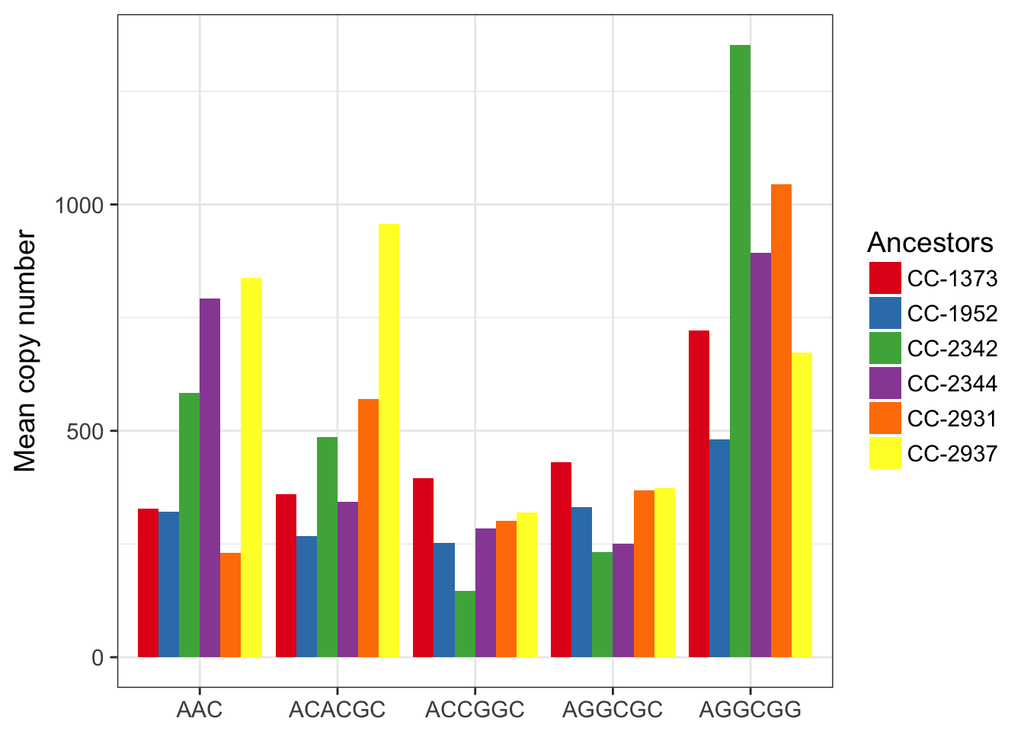

```r
Fig1_kmers <- c("AGGCGG", "AAC", "ACACGC", "ACCGGC", "AGGCGC")
Ancestors <- c(rep("CC-1373", times=5), rep("CC-1952", times=5), rep("CC-2342", times=5), rep("CC-2344", times=5), rep("CC-2931", times=5), rep("CC-2937", times=5))

#Ancestors

# make a data frame
means_1373 <- c()
means_1952 <- c()
means_2342 <- c()
means_2344 <- c()
means_2931 <- c()
means_2937 <- c()
for (i in 1:length(Fig1_kmers)) {
    means_1373 <- c(means_1373, mean(data_1373[,Fig1_kmers[i]]))
    means_1952 <- c(means_1952, mean(data_1952[,Fig1_kmers[i]]))
    means_2342 <- c(means_2342, mean(data_2342[,Fig1_kmers[i]]))
    means_2344 <- c(means_2344, mean(data_2344[,Fig1_kmers[i]]))
    means_2931 <- c(means_2931, mean(data_2931[,Fig1_kmers[i]]))
    means_2937 <- c(means_2937, mean(data_2937[,Fig1_kmers[i]]))
}
means_fig1 <- c(means_1373, means_1952, means_2342, means_2344, means_2931, means_2937)

Fig1_df <- data.frame(Ancestors, Fig1_kmers, means_fig1)

ggplot(Fig1_df, aes(fill=Ancestors, x=Fig1_kmers, y=means_fig1)) +
  geom_bar(position="dodge", stat="identity") +
  ylab("Mean copy number") +
  scale_fill_brewer(palette="Set1") +
  theme_bw(base_size = 14) +
  theme(axis.title.x=element_blank())
```

# Length and GC distribution of kmers

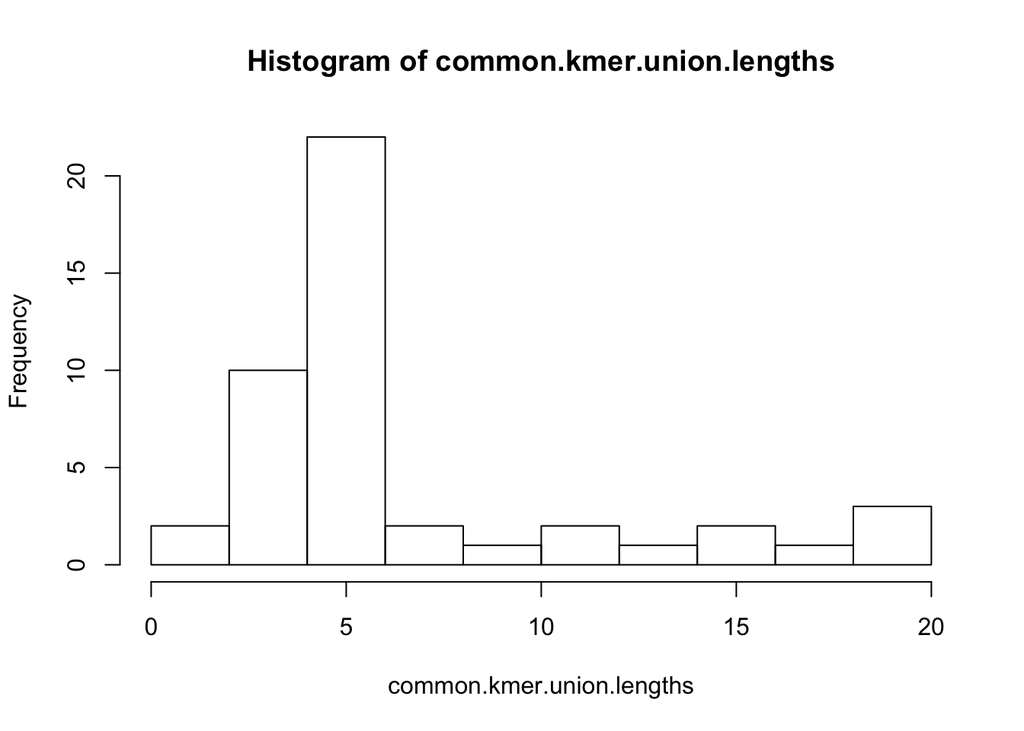

```r
# function to calculate length of string
Calc_kmer_length <- function (kmer_string) {
  return (nchar(kmer_string))
}

# function to calculate GC content of a kmer
Calc_GC_content <- function (kmer_string) {
  string <- BString(kmer_string)
  gc.content <- c(letterFrequency(string, letters=c("CG"), as.prob=F)/(length(string)))
  return(gc.content)
}

common.kmer.union.lengths <- sapply(common.kmer.union, Calc_kmer_length)
common.kmer.union.gc <- sapply(common.kmer.union, Calc_GC_content)

hist(common.kmer.union.lengths, breaks=11)
```

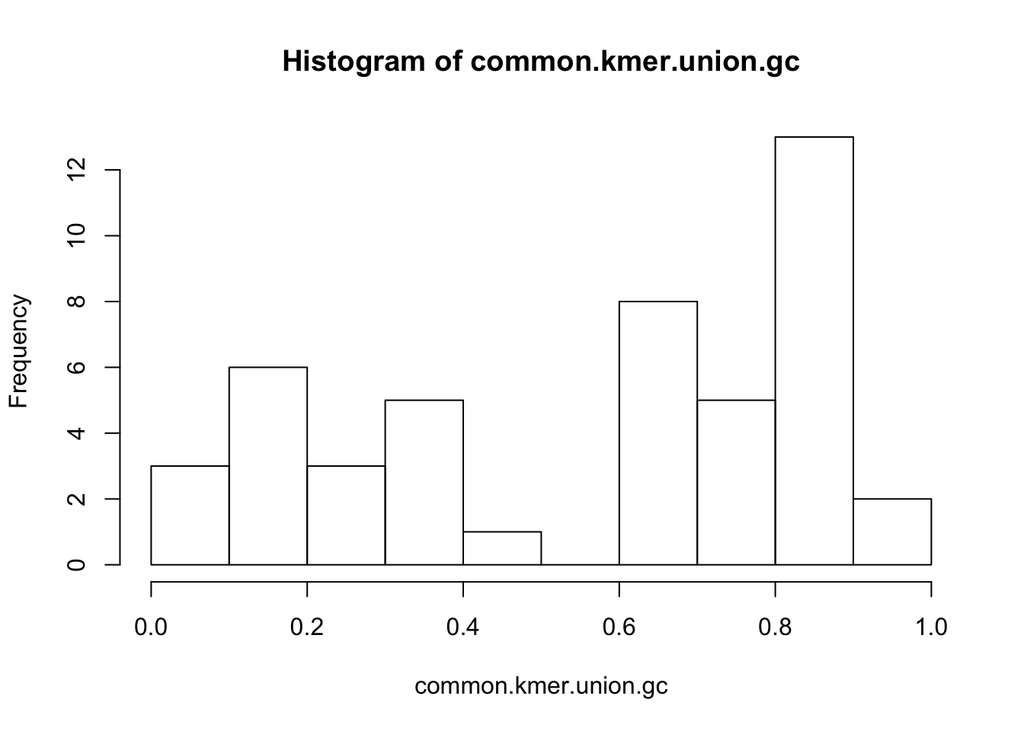

```r
hist(common.kmer.union.gc, breaks=10)
```

```r
# 6mers are the most abundant
length(which(common.kmer.union.lengths == 6))
```

```
## [1] 19
```

# Make Figure 2

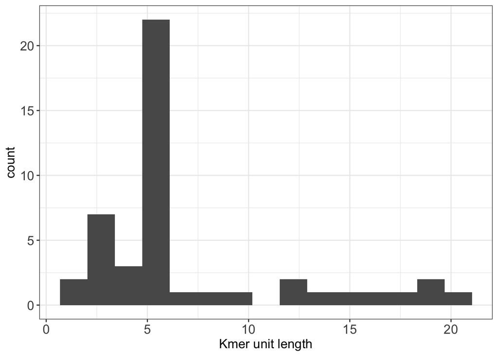

```r
qplot(x=common.kmer.union.lengths, geom="histogram", bins=15) + xlab("Kmer unit length") +
  theme_bw() +
  theme(axis.text = element_text(size=13), axis.title = element_text(size=13))
```

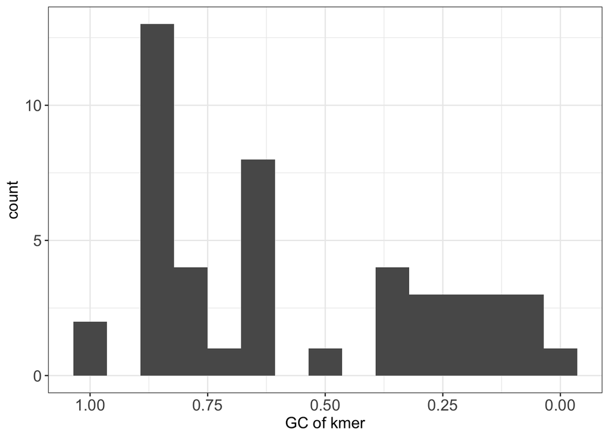

```r
qplot(x=common.kmer.union.gc, geom="histogram", bins=15) + scale_x_reverse() + xlab("GC of kmer") +
  theme_bw() +
  theme(axis.text = element_text(size=13), axis.title = element_text(size=13))
```

```r
# Make an extra table
table2 <- data.frame(common.kmer.union, common.kmer.union.lengths, common.kmer.union.gc)

#write.table(table2, file = "/Users/jullienflynn/Documents/AndyLab/Chlamy/ManuscriptFigures/Table2.txt", row.names = F, quote=F)
```

# Interesting pattern of GC content

Maybe some repeats are coming from the chloroplast given their GC contents and the previous finding that the chloroplast DOES contain repeats.

```r
mean(common.kmer.union.gc)
```

```
## [1] 0.5661754
```

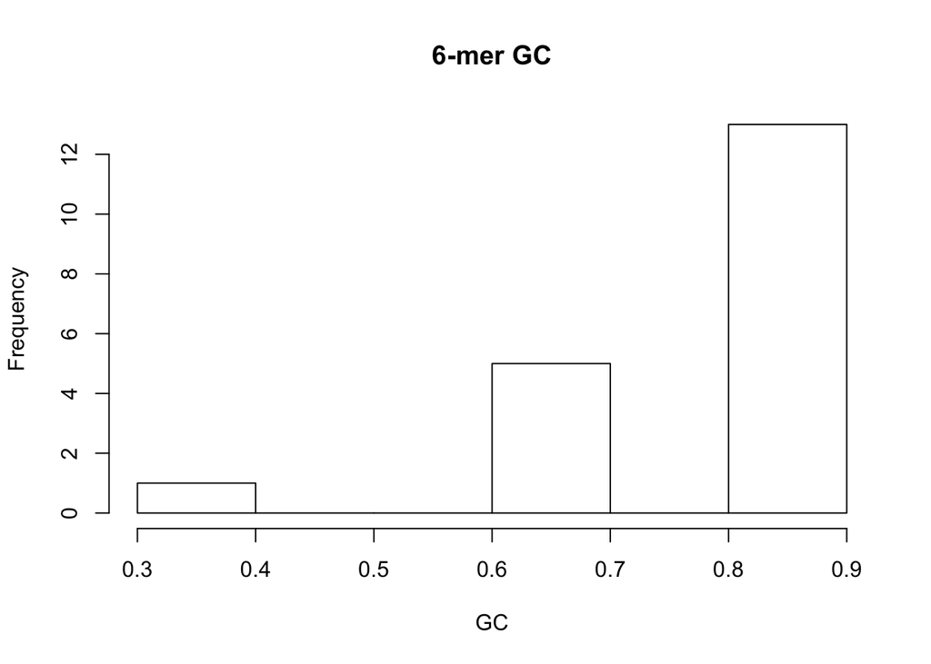

```r
hist (sapply (names(which(common.kmer.union.lengths == 6)), Calc_GC_content), main="6-mer GC", xlab="GC")
```

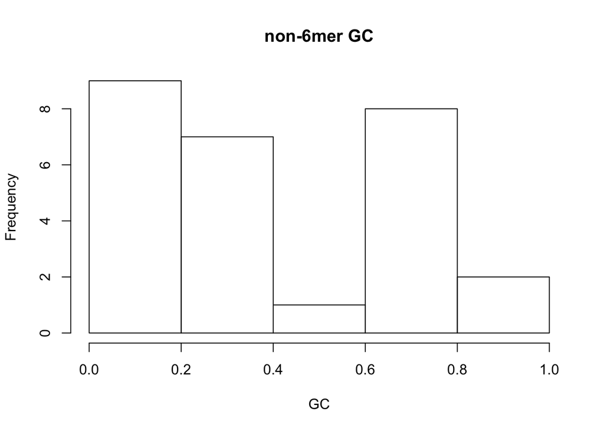

```r
hist (sapply (names(which(common.kmer.union.lengths != 6)), Calc_GC_content), main="non-6mer GC", xlab="GC")
```

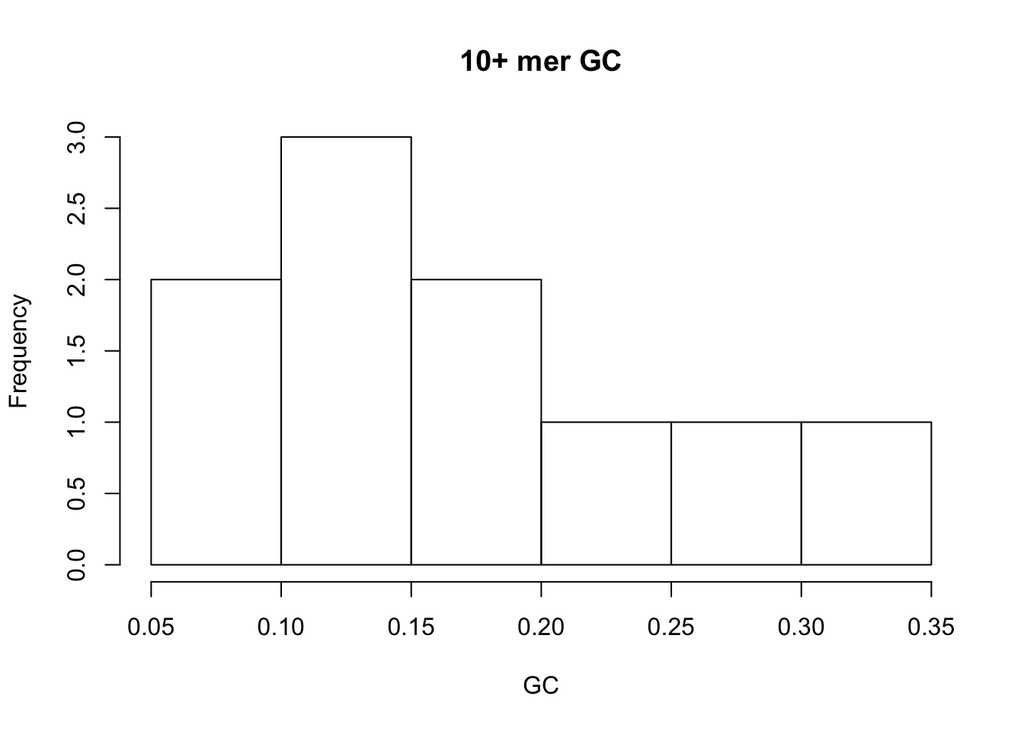

```r
# all the longer kmers >=10 bp are GC < 0.35
hist (sapply (names(which(common.kmer.union.lengths >= 10)), Calc_GC_content), main="10+ mer GC", xlab="GC")
```

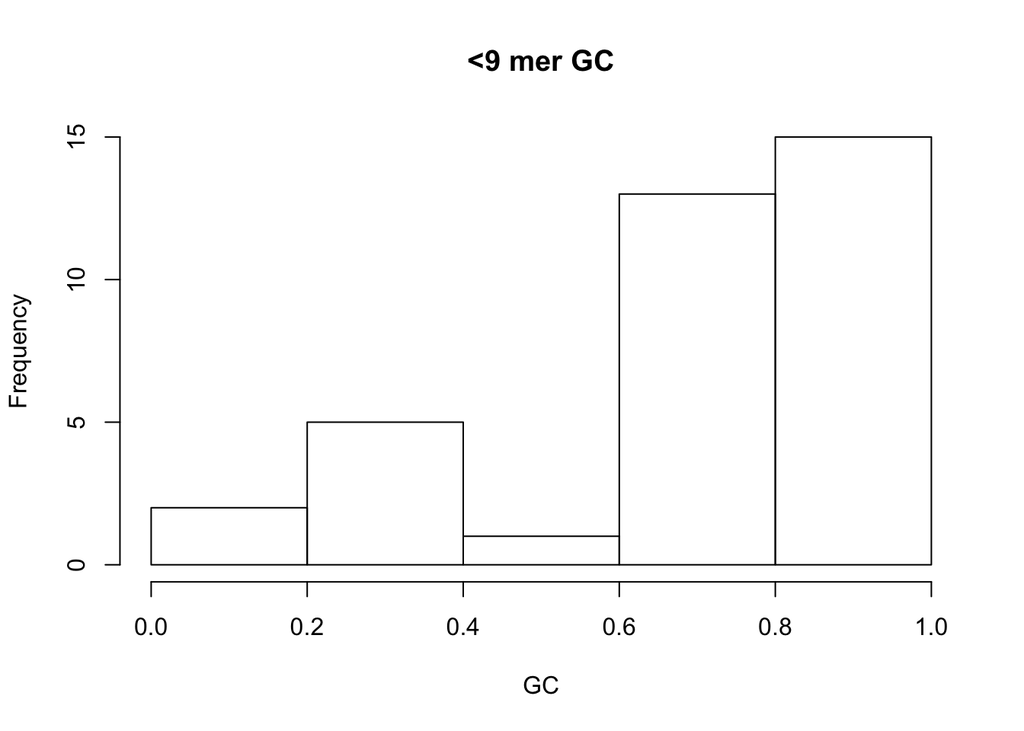

```r
hist (sapply (names(which(common.kmer.union.lengths <= 9)), Calc_GC_content), main="<9 mer GC", xlab="GC")
```

```r
length(which(common.kmer.union.lengths <= 9))
```

```
## [1] 36
```

```r
mean(sapply (names(which(common.kmer.union.lengths >= 10)), Calc_GC_content))
```

```
## [1] 0.1738116
```

```r
# average GC is 17.4 !!
max(sapply (names(which(common.kmer.union.lengths >= 10)), Calc_GC_content))
```

```
## [1] 0.3157895
```

```r
mean(sapply (names(which(common.kmer.union.lengths <= 9)), Calc_GC_content))
```

```
## [1] 0.6751653
```

```r
# make Figure 2c

assign_group <- function(length){
  if (length >= 10) {
    group <- 1
  }
  else {
    group <- 2
  }
  return(group)
}

group_assignments <- sapply (common.kmer.union.lengths, assign_group)
group_assignments
```

```
##                   AC                  AGC             AAAACCCT
##                    2                    2                    2
##                    C               AGGCGG                  AAT
##                    2                    2                    2
##                 AGGC                 ACGC                  AAC
##                    2                    2                    2
##               ACACGC  AAATACCTTACGGGAATAT               AGGCGC
##                    2                    1                    2
##               ACCGGC                  CCG                  ACC
##                    2                    2                    2
##                AGGGC               ACCCGC           AAATAACAAT
##                    2                    2                    1
##               AGCGGC                AAAGT                  AGG
##                    2                    2                    2
##               ACAGGG                  ATC               ACGCCC
##                    2                    2                    2
##   AAATACTTACGGGAATAT               AGCGCC               AGCGGG
##                    1                    2                    2
##               ACCCGG      AAATTTATATACTCC               ACAGGC
##                    2                    1                    2
##               ACCAGC     AAAGAAGTATATAAAT  AAAATATATAAATATAGCT
##                    2                    1                    1
##               AGCCGG               AGCCGC         AATAGATAATAT
##                    2                    2                    1
##       AAATAGCAGTATAT AAAAAGGTAAATGTATTTAT                ACGCC
##                    1                    1                    2
##               AGGGCC               AGGGGC               AGAGGC
##                    2                    2                    2
##         AAAATAAAGTGT              ACTGGGC               AAACAC
##                    1                    2                    2
##                 AAAC
##                    2
```

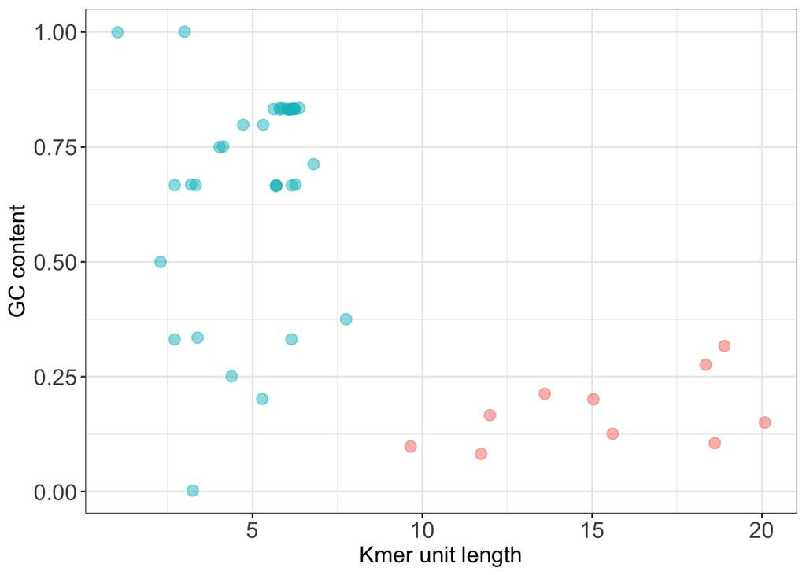

```r
cp_plot <- data.frame(lengths=common.kmer.union.lengths, gc=common.kmer.union.gc, grp=as.factor(group_assignments))

ggplot (data = cp_plot, aes(y = cp_plot$gc, x = cp_plot$lengths, color = cp_plot$grp )) +
  geom_jitter(size=3, alpha=0.5) +
  xlab("Kmer unit length") +
  ylab("GC content") +
  theme_bw() +
  theme(axis.text = element_text(size=14), axis.title = element_text(size=14), legend.position="none")
```

# Differences in the abundance of the telomere repeat

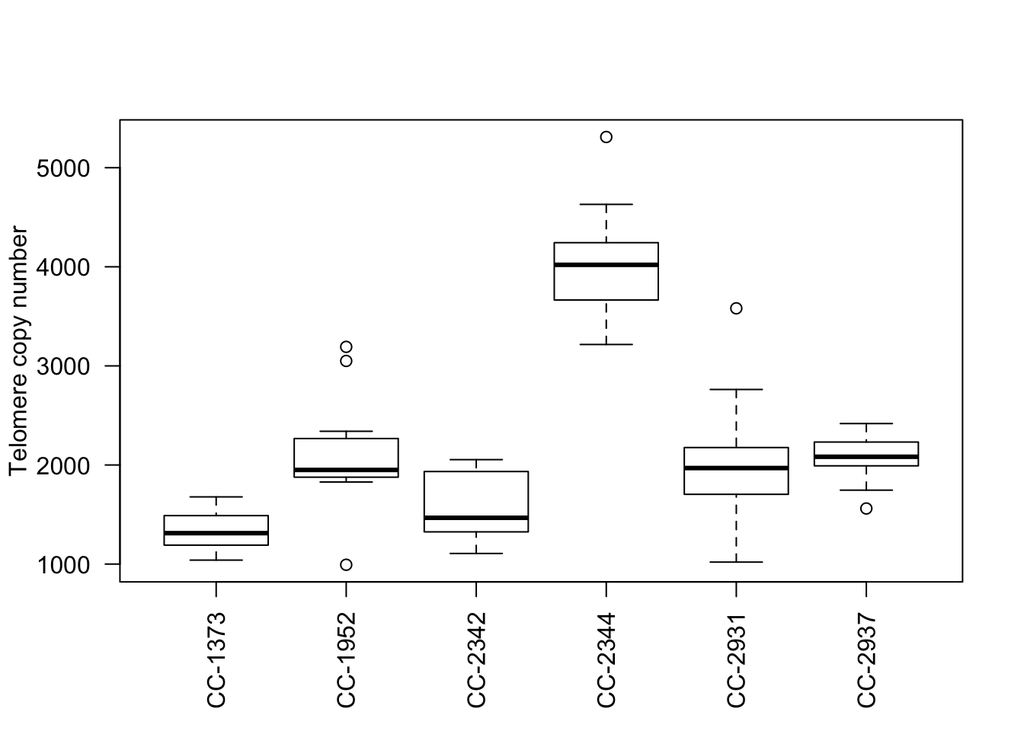

```r
temp <- which(colnames (data_1373)=="AAAACCCT")
telomere_abun_1373 <- data.frame(data_1373[,temp], "CC-1373")
colnames(telomere_abun_1373) <- c("copynumber", "Ancestor")
telomere_mean_1373 <- mean(data_1373[,temp])

temp <- which(colnames (data_1952)=="AAAACCCT")
telomere_abun_1952 <- data.frame(data_1952[,temp], "CC-1952")
colnames(telomere_abun_1952) <- c("copynumber", "Ancestor")
telomere_mean_1952 <- mean(data_1952[,temp])

temp <- which(colnames (data_2342)=="AAAACCCT")
telomere_abun_2342 <- data.frame(data_2342[,temp], "CC-2342")
colnames(telomere_abun_2342) <- c("copynumber", "Ancestor")
telomere_mean_2342 <- mean(data_2342[,temp])

temp <- which(colnames (data_2344)=="AAAACCCT")
telomere_abun_2344 <- data.frame(data_2344[,temp], "CC-2344")
colnames(telomere_abun_2344) <- c("copynumber", "Ancestor")
telomere_mean_2344 <- mean(data_2344[,temp])

temp <- which(colnames (data_2931)=="AAAACCCT")
telomere_abun_2931 <- data.frame(data_2931[,temp], "CC-2931")
colnames(telomere_abun_2931) <- c("copynumber", "Ancestor")
telomere_mean_2931 <- mean(data_2931[,temp])

temp <- which(colnames (data_2937)=="AAAACCCT")
telomere_abun_2937 <- data.frame(data_2937[,temp], "CC-2937")
colnames(telomere_abun_2937) <- c("copynumber", "Ancestor")
telomere_mean_2937 <- mean(data_2937[,temp])

telomere_abun_df <- rbind(telomere_abun_1373, telomere_abun_1952, telomere_abun_2342,
                          telomere_abun_2344, telomere_abun_2931, telomere_abun_2937)

boxplot(telomere_abun_df[,1] ~ telomere_abun_df[,2], data=telomere_abun_df, las=2, ylab = "Telomere copy number")
```

```r
# seems like CC-2344 has higher telomere copy numbers

telomere_model <- aov(copynumber ~ Ancestor, data = telomere_abun_df)
summary(telomere_model)
```

```
##             Df   Sum Sq  Mean Sq F value Pr(>F)
## Ancestor     5 65453584 13090717   63.77 <2e-16 ***
## Residuals   79 16217709   205287
## ---
## Signif. codes:  0 '***' 0.001 '**' 0.01 '*' 0.05 '.' 0.1 ' ' 1
```

```r
# anova indicates significant difference
posthoc_telomere <- TukeyHSD(x=telomere_model, conf.level = 0.95)
posthoc_telomere
```

```
##   Tukey multiple comparisons of means
##     95% family-wise confidence level
##
## Fit: aov(formula = copynumber ~ Ancestor, data = telomere_abun_df)
##
## $Ancestor
##                        diff        lwr          upr     p adj
## CC-1952-CC-1373   784.20879   274.4852  1293.932358 0.0003319
## CC-2342-CC-1373   291.49451  -218.2291   801.218072 0.5552132
## CC-2344-CC-1373  2700.72308  2199.2470  3202.199172 0.0000000
## CC-2931-CC-1373   684.35165   174.6281  1194.075215 0.0024886
## CC-2937-CC-1373   767.78974   266.3136  1269.265838 0.0003595
## CC-2342-CC-1952  -492.71429  -992.9095     7.480897 0.0559447
## CC-2344-CC-1952  1916.51429  1424.7263  2408.302228 0.0000000
## CC-2931-CC-1952   -99.85714  -600.0523   400.338040 0.9918848
## CC-2937-CC-1952   -16.41905  -508.2070   475.368895 0.9999987
## CC-2344-CC-2342  2409.22857  1917.4406  2901.016514 0.0000000
## CC-2931-CC-2342   392.85714  -107.3380   893.052326 0.2088176
## CC-2937-CC-2342   476.29524   -15.4927   968.083181 0.0632172
## CC-2931-CC-2344 -2016.37143 -2508.1594 -1524.583486 0.0000000
## CC-2937-CC-2344 -1932.93333 -2416.1678 -1449.698877 0.0000000
## CC-2937-CC-2931    83.43810  -408.3498   575.226038 0.9962013
```

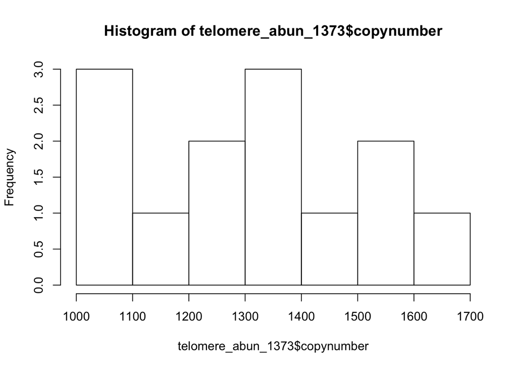

```r
help("TukeyHSD")
hist(telomere_abun_1373$copynumber)
```

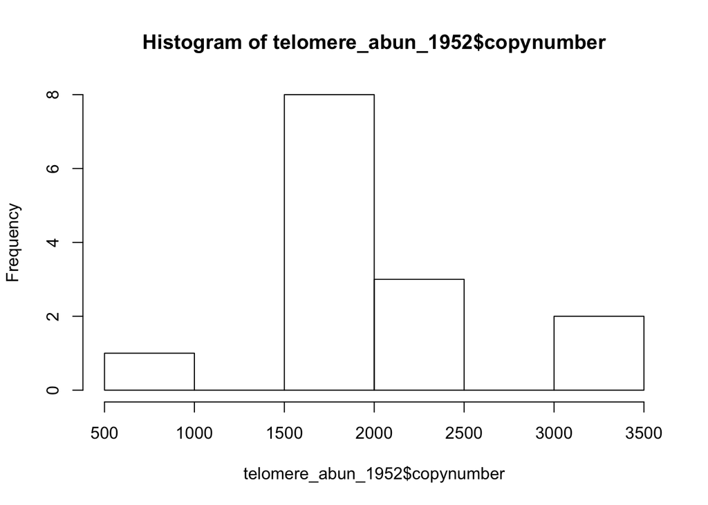

```r
hist(telomere_abun_1952$copynumber)
```

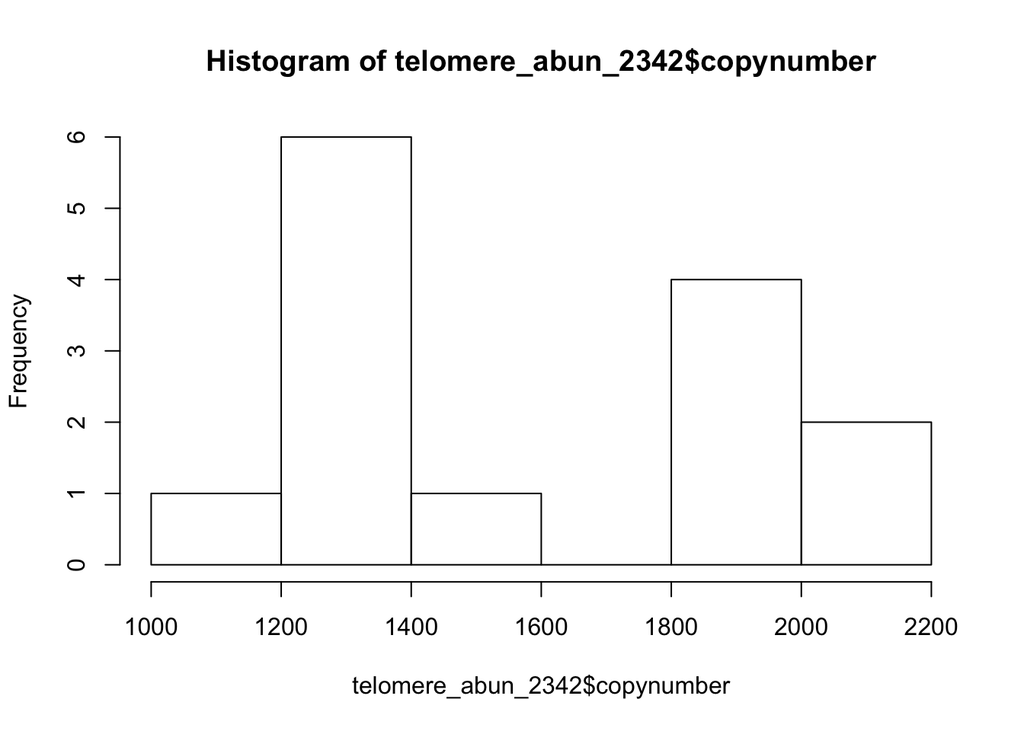

```r
hist(telomere_abun_2342$copynumber)
```

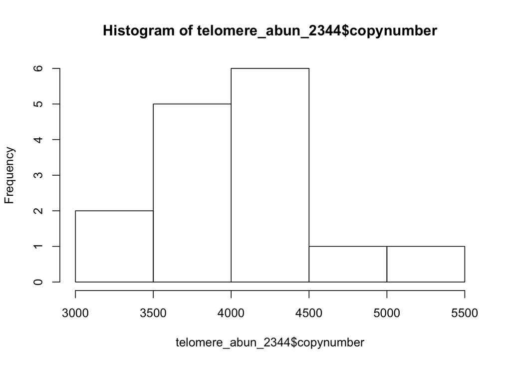

```r
hist(telomere_abun_2344$copynumber)
```

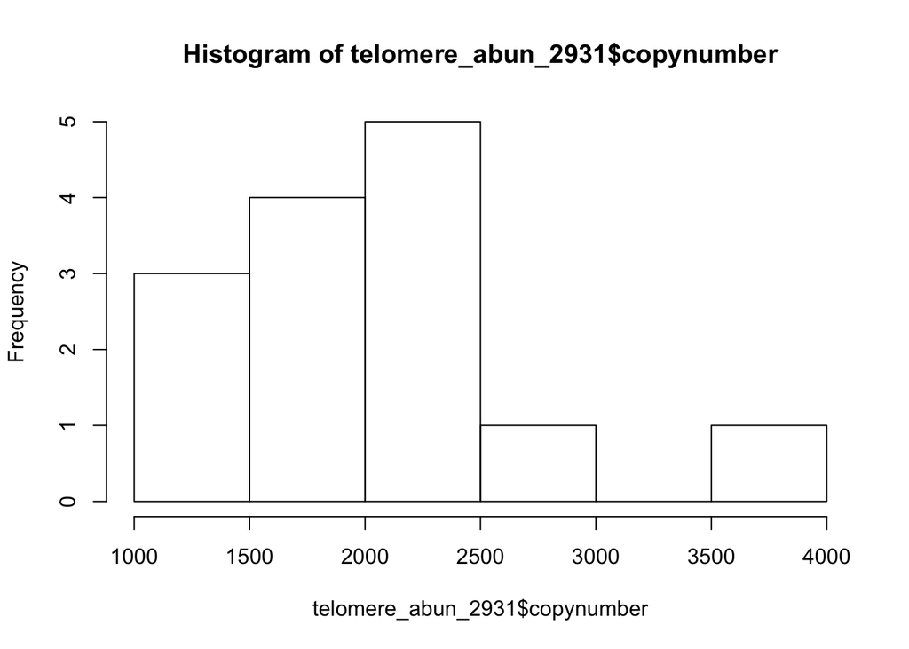

```r
hist(telomere_abun_2931$copynumber)
```

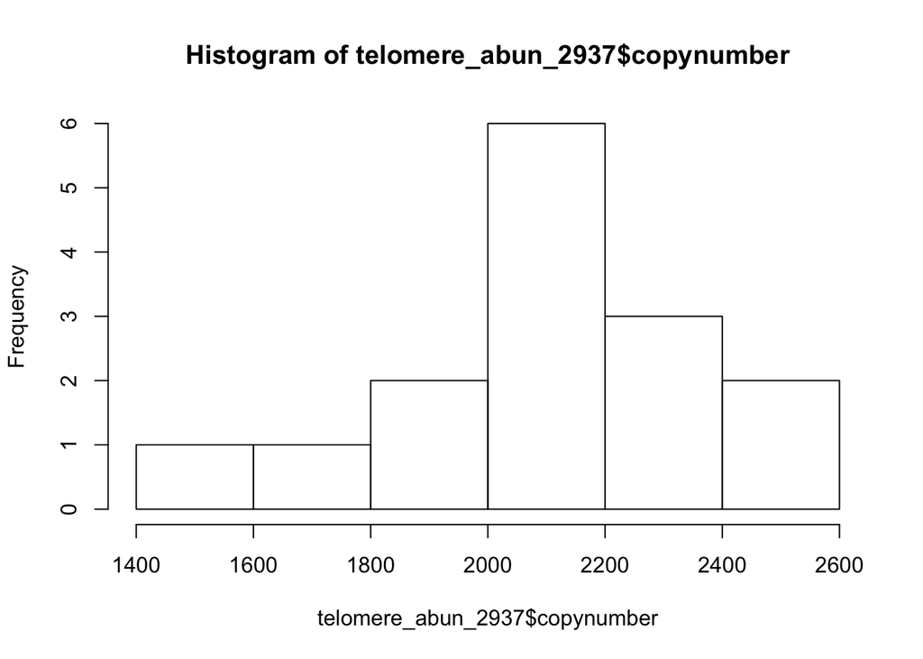

```r
hist(telomere_abun_2937$copynumber)
```

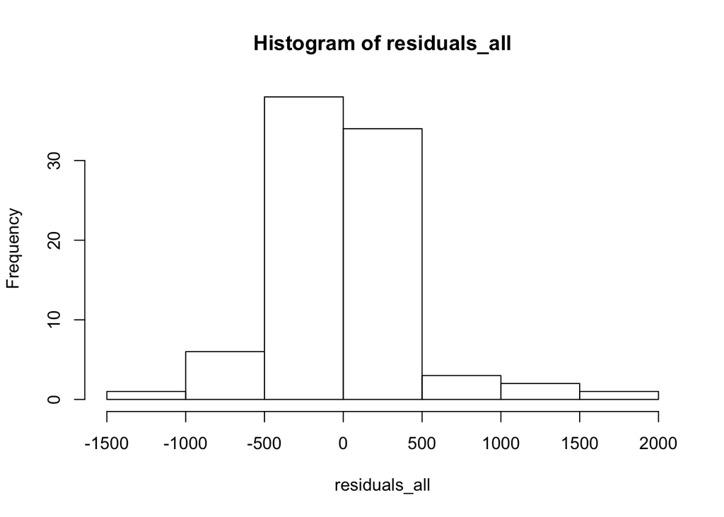

```r
get_residuals <- function (abun_mx) {
  x <- abun_mx$copynumber - mean(abun_mx$copynumber)
  return(x)
}
residuals_1373 <- get_residuals(telomere_abun_1373)
residuals_1952 <- get_residuals(telomere_abun_1952)
residuals_2342 <- get_residuals(telomere_abun_2342)
residuals_2344 <- get_residuals(telomere_abun_2344)
residuals_2931 <- get_residuals(telomere_abun_2931)
residuals_2937 <- get_residuals(telomere_abun_2937)
residuals_all <- c(residuals_1373, residuals_1952, residuals_2342, residuals_2344, residuals_2931, residuals_2937)
hist(residuals_all)
```

```r
# great, the residuals are approximately normally distributed, parametric test is fine to do
```

# Kmers that are polymorphic by presence/absence

```r
# For Figure 1B
mean(data_1373[,"AAATACCTTACGGGAATAT"])
```

```
## [1] 390.2308
```

```r
mean(data_1952[,"AAATACCTTACGGGAATAT"])
```

```
## [1] 509.1429
```

```r
mean(data_2342[,"AAATACCTTACGGGAATAT"])
```

```
## [1] 0.07142857
```

```r
mean(data_2344[,"AAATACCTTACGGGAATAT"])
```

```
## [1] 170.9333
```

```r
mean(data_2931[,"AAATACCTTACGGGAATAT"])
```

```
## [1] 0.5714286
```

```r
mean(data_2937[,"AAATACCTTACGGGAATAT"])
```

```
## [1] 929.4
```

```r
mean(data_1373[,"AAATAACAAT"])
```

```
## [1] 1203.462
```

```r
mean(data_1952[,"AAATAACAAT"])
```

```
## [1] 0.4285714
```

```r
mean(data_2342[,"AAATAACAAT"])
```

```
## [1] 0.1428571
```

```r
mean(data_2344[,"AAATAACAAT"])
```

```
## [1] 0.1333333
```

```r
mean(data_2931[,"AAATAACAAT"])
```

```
## [1] 0.1428571
```

```r
mean(data_2937[,"AAATAACAAT"])
```

```
## [1] 0.06666667
```

```r
mean(data_1373[,"ATC"])
```

```
## [1] 275.2308
```

```r
mean(data_1952[,"ATC"])
```

```
## [1] 108.0714
```

```r
mean(data_2342[,"ATC"])
```

```
## [1] 0.1428571
```

```r
mean(data_2344[,"ATC"])
```

```
## [1] 76.93333
```

```r
mean(data_2931[,"ATC"])
```

```
## [1] 323.7857
```

```r
mean(data_2937[,"ATC"])
```

```
## [1] 34.26667
```

```r
mean(data_1373[,"AAATACTTACGGGAATAT"])
```

```
## [1] 351.3077
```

```r
mean(data_1952[,"AAATACTTACGGGAATAT"])
```

```
## [1] 148.0714
```

```r
mean(data_2342[,"AAATACTTACGGGAATAT"])
```

```
## [1] 0.1428571
```

```r
mean(data_2344[,"AAATACTTACGGGAATAT"])
```

```
## [1] 0.1333333
```

```r
mean(data_2931[,"AAATACTTACGGGAATAT"])
```

```
## [1] 0.07142857
```

```r
mean(data_2937[,"AAATACTTACGGGAATAT"])
```

```
## [1] 171.3333
```

```r
mean(data_1373[,"ACCCGG"])
```

```
## [1] 103.3846
```

```r
mean(data_1952[,"ACCCGG"])
```

```
## [1] 0
```

```r
mean(data_2342[,"ACCCGG"])
```

```
## [1] 7.642857
```

```r
mean(data_2344[,"ACCCGG"])
```

```
## [1] 0
```

```r
mean(data_2931[,"ACCCGG"])
```

```
## [1] 0
```

```r
mean(data_2937[,"ACCCGG"])
```

```
## [1] 72.13333
```

```r
mean(data_1373[,"AAATTTATATACTCC"])
```

```
## [1] 0.1538462
```

```r
mean(data_1952[,"AAATTTATATACTCC"])
```

```
## [1] 1079.571
```

```r
mean(data_2342[,"AAATTTATATACTCC"])
```

```
## [1] 0.5
```

```r
mean(data_2344[,"AAATTTATATACTCC"])
```

```
## [1] 597.2
```

```r
mean(data_2931[,"AAATTTATATACTCC"])
```

```
## [1] 0
```

```r
mean(data_2937[,"AAATTTATATACTCC"])
```

```
## [1] 0.2
```

```r
mean(data_1373[,"AAAGAAGTATATAAAT"])
```

```
## [1] 0.2307692
```

```r
mean(data_1952[,"AAAGAAGTATATAAAT"])
```

```
## [1] 902.0714
```

```r
mean(data_2342[,"AAAGAAGTATATAAAT"])
```

```
## [1] 0.1428571
```

```r
mean(data_2344[,"AAAGAAGTATATAAAT"])
```

```
## [1] 0.06666667
```

```r
mean(data_2931[,"AAAGAAGTATATAAAT"])
```

```
## [1] 0.1428571
```

```r
mean(data_2937[,"AAAGAAGTATATAAAT"])
```

```
## [1] 0.1333333
```

```r
mean(data_1373[,"AAAATATATAAATATAGCT"])
```

```
## [1] 0.1538462
```

```r
mean(data_1952[,"AAAATATATAAATATAGCT"])
```

```
## [1] 583.2143
```

```r
mean(data_2342[,"AAAATATATAAATATAGCT"])
```

```
## [1] 0.07142857
```

```r
mean(data_2344[,"AAAATATATAAATATAGCT"])
```

```
## [1] 74.13333
```

```r
mean(data_2931[,"AAAATATATAAATATAGCT"])
```

```
## [1] 0
```

```r
mean(data_2937[,"AAAATATATAAATATAGCT"])
```

```
## [1] 0.06666667
```

```r
mean(data_1373[,"AATAGATAATAT"])
```

```
## [1] 0
```

```r
mean(data_1952[,"AATAGATAATAT"])
```

```
## [1] 111.7857
```

```r
mean(data_2342[,"AATAGATAATAT"])
```

```
## [1] 0
```

```r
mean(data_2344[,"AATAGATAATAT"])
```

```
## [1] 0.06666667
```

```r
mean(data_2931[,"AATAGATAATAT"])
```

```
## [1] 0
```

```r
mean(data_2937[,"AATAGATAATAT"])
```

```
## [1] 0.06666667
```

```r
mean(data_1373[,"AAATAGCAGTATAT"])
```

```
## [1] 0.6153846
```

```r
mean(data_1952[,"AAATAGCAGTATAT"])
```

```
## [1] 0.2857143
```

```r
mean(data_2342[,"AAATAGCAGTATAT"])
```

```
## [1] 1925.643
```

```r
mean(data_2344[,"AAATAGCAGTATAT"])
```

```
## [1] 0.5333333
```

```r
mean(data_2931[,"AAATAGCAGTATAT"])
```

```
## [1] 1896.286
```

```r
mean(data_2937[,"AAATAGCAGTATAT"])
```

```
## [1] 0.4
```

```r
mean(data_1373[,"AAAAAGGTAAATGTATTTAT"])
```

```
## [1] 0.1538462
```

```r
mean(data_1952[,"AAAAAGGTAAATGTATTTAT"])
```

```
## [1] 0.07142857
```

```r
mean(data_2342[,"AAAAAGGTAAATGTATTTAT"])
```

```
## [1] 346
```

```r
mean(data_2344[,"AAAAAGGTAAATGTATTTAT"])
```

```
## [1] 0.06666667
```

```r
mean(data_2931[,"AAAAAGGTAAATGTATTTAT"])
```

```
## [1] 317.7857
```

```r
mean(data_2937[,"AAAAAGGTAAATGTATTTAT"])
```

```
## [1] 0.2
```

```r
mean(data_1373[,"AAAAAGGTAAATGTATTTAT"])
```

```
## [1] 0.1538462
```

```r
mean(data_1952[,"AAAAAGGTAAATGTATTTAT"])
```

```
## [1] 0.07142857
```

```r
mean(data_2342[,"AAAAAGGTAAATGTATTTAT"])
```

```
## [1] 346
```

```r
mean(data_2344[,"AAAAAGGTAAATGTATTTAT"])
```

```
## [1] 0.06666667
```

```r
mean(data_2931[,"AAAAAGGTAAATGTATTTAT"])
```

```
## [1] 317.7857
```

```r
mean(data_2937[,"AAAAAGGTAAATGTATTTAT"])
```

```
## [1] 0.2
```

```r
mean(data_1373[,"AGGGCC"])
```

```
## [1] 0.2307692
```

```r
mean(data_1952[,"AGGGCC"])
```

```
## [1] 33.14286
```

```r
mean(data_2342[,"AGGGCC"])
```

```
## [1] 386.2143
```

```r
mean(data_2344[,"AGGGCC"])
```

```
## [1] 9.4
```

```r
mean(data_2931[,"AGGGCC"])
```

```
## [1] 13.21429
```

```r
mean(data_2937[,"AGGGCC"])
```

```
## [1] 1.466667
```

```r
mean(data_1373[,"AGAGGC"])
```

```
## [1] 3
```

```r
mean(data_1952[,"AGAGGC"])
```

```
## [1] 1.5
```

```r
mean(data_2342[,"AGAGGC"])
```

```
## [1] 125.0714
```

```r
mean(data_2344[,"AGAGGC"])
```

```
## [1] 0
```

```r
mean(data_2931[,"AGAGGC"])
```

```
## [1] 0
```

```r
mean(data_2937[,"AGAGGC"])
```

```
## [1] 7.733333
```

```r
mean(data_1373[,"AAAATAAAGTGT"])
```

```
## [1] 0.2307692
```

```r
mean(data_1952[,"AAAATAAAGTGT"])
```

```
## [1] 0.8571429
```

```r
mean(data_2342[,"AAAATAAAGTGT"])
```

```
## [1] 0.3571429
```

```r
mean(data_2344[,"AAAATAAAGTGT"])
```

```
## [1] 846.1333
```

```r
mean(data_2931[,"AAAATAAAGTGT"])
```

```
## [1] 646.2857
```

```r
mean(data_2937[,"AAAATAAAGTGT"])
```

```
## [1] 0.4666667
```

```r
mean(data_1373[,"ACTGGGC"])
```

```
## [1] 0
```

```r
mean(data_1952[,"ACTGGGC"])
```

```
## [1] 0
```

```r
mean(data_2342[,"ACTGGGC"])
```

```
## [1] 0
```

```r
mean(data_2344[,"ACTGGGC"])
```

```
## [1] 0
```

```r
mean(data_2931[,"ACTGGGC"])
```

```
## [1] 121.1429
```

```r
mean(data_2937[,"ACTGGGC"])
```

```
## [1] 0
```

```r
mean(data_1373[,"AAACAC"])
```

```
## [1] 8.461538
```

```r
mean(data_1952[,"AAACAC"])
```

```
## [1] 0
```

```r
mean(data_2342[,"AAACAC"])
```

```
## [1] 26.71429
```

```r
mean(data_2344[,"AAACAC"])
```

```
## [1] 5.666667
```

```r
mean(data_2931[,"AAACAC"])
```

```
## [1] 58.28571
```

```r
mean(data_2937[,"AAACAC"])
```

```
## [1] 131.6
```

```r
mean(data_1373[,"AAAC"])
```

```
## [1] 7.846154
```

```r
mean(data_1952[,"AAAC"])
```

```
## [1] 0
```

```r
mean(data_2342[,"AAAC"])
```

```
## [1] 29
```

```r
mean(data_2344[,"AAAC"])
```

```
## [1] 0
```

```r
mean(data_2931[,"AAAC"])
```

```
## [1] 0.2142857
```

```r
mean(data_2937[,"AAAC"])
```

```
## [1] 170.4
```

# Get total kmer content

For each ancestral lineage, get the absolute amount of kmer content in kb. Use all the kmers that have at least 2 copies (normalized) in all the MA lines

```r
# get kmers that will be used for the overall genome-wide description of kmers in the 6 ancestors
# have at least 2 normalized copies in all MA lines from the a given ancestor

get_legit_kmer_indexes <- function (kmer_mx) {
  indexes <- c()
  for (i in 1:ncol(kmer_mx)) { ## go through each column of the data
    p <- kmer_mx[,i] >= 2 ## at least 2 copies
    if (sum(p)==nrow(kmer_mx)) { # if all samples have at least 2 copies
      indexes <- c(indexes, i)
    }
  }
  return(indexes)
}
#get matrix with absolute kmer content (multiplied by length of kmer)

get_abskmer_mx <- function (kmer_mx, indexes) {
  kmers.abs <- matrix(nrow=nrow(kmer_mx), ncol=max(indexes))
  for (i in indexes) {
    for (j in 1:nrow(kmer_mx)) {
    kmers.abs[j,i] <- kmer_mx[j,i] * (nchar(colnames(kmer_mx)[i], type="chars"))
    }
  }
  kmers.abs <- kmers.abs[,colSums(is.na(kmers.abs)) != nrow(kmers.abs)] # get rid of columns that are all NAs
  return(kmers.abs)
}

# get total kmer content per MA line
get_total_kmercontent <- function (abs_mx) {
  total.kmers.abs <- c()
  for (i in 1:nrow(abs_mx)){
    total.kmers.abs[i] <- sum(abs_mx[i,])/10^3
  }
  names(total.kmers.abs) <- rownames(abs_mx)
  return (total.kmers.abs)
}


legit.kmer.indexes_1373 <- get_legit_kmer_indexes(data_1373)
length(legit.kmer.indexes_1373)
```

```
## [1] 150
```

```r
abs.mx_1373 <- get_abskmer_mx(data_1373, legit.kmer.indexes_1373)
total.kmercontent_1373 <- get_total_kmercontent(abs.mx_1373)
mean(total.kmercontent_1373)
```

```
## [1] 149.2864
```

```r
total.kmercontent_1373 # note: this is in kb
```

```
##  [1] 159.611 150.749 153.285 134.614 161.199 134.988 141.093 131.020
##  [9] 163.460 178.961 127.271 172.295 132.177
```

```r
legit.kmer.indexes_1952 <- get_legit_kmer_indexes(data_1952)
length(legit.kmer.indexes_1952)
```

```
## [1] 134
```

```r
abs.mx_1952 <- get_abskmer_mx(data_1952, legit.kmer.indexes_1952)
total.kmercontent_1952 <- get_total_kmercontent(abs.mx_1952)
mean(total.kmercontent_1952) # note: this is in kb
```

```
## [1] 186.5406
```

```r
legit.kmer.indexes_2342 <- get_legit_kmer_indexes(data_2342)
length(legit.kmer.indexes_2342)
```

```
## [1] 134
```

```r
abs.mx_2342 <- get_abskmer_mx(data_2342, legit.kmer.indexes_2342)
total.kmercontent_2342 <- get_total_kmercontent(abs.mx_2342)
mean(total.kmercontent_2342) # note: this is in kb
```

```
## [1] 189.7683
```

```r
legit.kmer.indexes_2344 <- get_legit_kmer_indexes(data_2344)
length(legit.kmer.indexes_2344)
```

```
## [1] 170
```

```r
abs.mx_2344 <- get_abskmer_mx(data_2344, legit.kmer.indexes_2344)
total.kmercontent_2344 <- get_total_kmercontent(abs.mx_2344)
mean(total.kmercontent_2344)
```

```
## [1] 192.691
```

```r
legit.kmer.indexes_2931 <- get_legit_kmer_indexes(data_2931)
length(legit.kmer.indexes_2931)
```

```
## [1] 171
```

```r
abs.mx_2931 <- get_abskmer_mx(data_2931, legit.kmer.indexes_2931)
total.kmercontent_2931 <- get_total_kmercontent(abs.mx_2931)
mean(total.kmercontent_2931)
```

```
## [1] 190.8386
```

```r
legit.kmer.indexes_2937 <- get_legit_kmer_indexes(data_2937)
length(legit.kmer.indexes_2937)
```

```
## [1] 198
```

```r
abs.mx_2937 <- get_abskmer_mx(data_2937, legit.kmer.indexes_2937)
total.kmercontent_2937 <- get_total_kmercontent(abs.mx_2937)
mean(total.kmercontent_2937)
```

```
## [1] 173.7612
```

```r
# Now, make a boxplot of this.

category <- c(
  rep ("CC-1373", times = nrow(data_1373)),
  rep ("CC-1952", times = nrow(data_1952)),
  rep ("CC-2342", times = nrow(data_2342)),
  rep ("CC-2344", times = nrow(data_2344)),
  rep ("CC-2931", times = nrow(data_2931)),
  rep ("CC-2937", times = nrow(data_2937))
  )

total.kmercontent_all <- c(total.kmercontent_1373, total.kmercontent_1952, total.kmercontent_2342, total.kmercontent_2344, total.kmercontent_2931, total.kmercontent_2937)
length(total.kmercontent_all)
```

```
## [1] 85
```

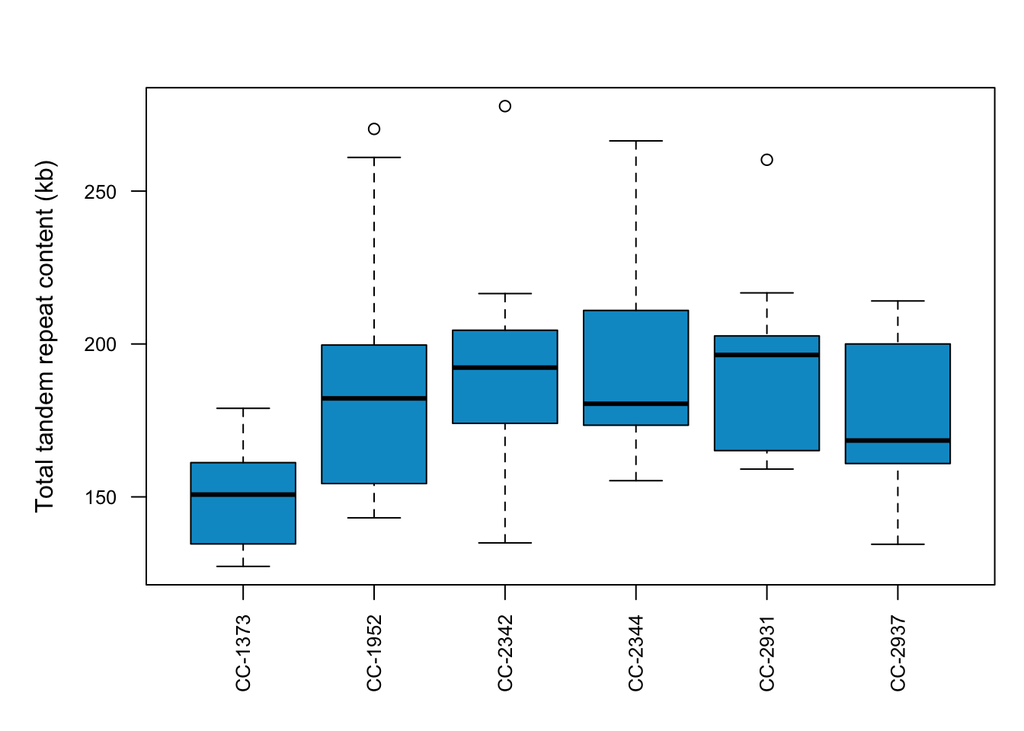

```r
TotalAbs_df <- data.frame (total.kmercontent_all, category)
par(mar=c(5,5,3,1))
boxplot (TotalAbs_df[,1] ~ TotalAbs_df[,2], data=TotalAbs_df, las=2, cex.axis=0.8, ylab="Total tandem repeat content (kb)", Main = "Per MA line absolute total mutation rate", col="deepskyblue3")
```

## Do the kmers that have similar patterns of correlation in multiple MA ancestors have similar copy number?

i.e. could similarity in mean copy number explain the similarity in correlation patterns.  
ANSWER: NO.

```r
shared_corr_kmers <- c("AGGC", "AGGCGG", "ACGC", "ACGCC", "ACGCCC", "ACCGCC", "ACCCGC", "ACACGC", "ACAGGC", "ACAGGG", "ACCAGC", "AGGCGC")

data_1373[,shared_corr_kmers]
```

```
##              AGGC AGGCGG ACGC ACGCC ACGCCC ACCGCC ACCCGC ACACGC ACAGGC
## CC-1373_MA1   492    659  367    74    120      6    128    374     76
## CC-1373_MA2   584    698  362    97     92     33    154    331     82
## CC-1373_MA3   535    741  499   149    146     39    203    432     94
## CC-1373_MA4   656    772  534   106    149      0    113    375    100
## CC-1373_MA5   455    664  324    55    105     14    120    360     60
## CC-1373_MA6   615    683  334    61     97     23    153    344     73
## CC-1373_MA7   446    714  297    41     75     33     99    296     63
## CC-1373_MA8   440    626  300    79    129     16    107    263     63
## CC-1373_MA10  650    793  538   104    150     15    202    468    102
## CC-1373_MA11  441    904  353    43     80     13    104    370     72
## CC-1373_MA13  459    635  256    46     83     19     79    258     76
## CC-1373_MA14  579    849  534   105    175     31    150    452     90
## CC-1373_MA15  472    634  397    56    109     31    116    352     72
##              ACAGGG ACCAGC AGGCGC
## CC-1373_MA1     123     82    449
## CC-1373_MA2     131     94    447
## CC-1373_MA3     161    148    358
## CC-1373_MA4     125     87    222
## CC-1373_MA5     113     92    515
## CC-1373_MA6     144     80    408
## CC-1373_MA7     109     74    476
## CC-1373_MA8     121     59    512
## CC-1373_MA10    191    125    403
## CC-1373_MA11    156     80    463
## CC-1373_MA13     92     68    506
## CC-1373_MA14    169    115    394
## CC-1373_MA15    114     70    438
```

```r
shared_corr_kmers_1373_means <- colMeans(data_1373[,shared_corr_kmers])
shared_corr_kmers_1373_means
```

```
##      AGGC    AGGCGG      ACGC     ACGCC    ACGCCC    ACCGCC    ACCCGC
## 524.92308 720.92308 391.92308  78.15385 116.15385  21.00000 132.92308
##    ACACGC    ACAGGC    ACAGGG    ACCAGC    AGGCGC
## 359.61538  78.69231 134.53846  90.30769 430.07692
```

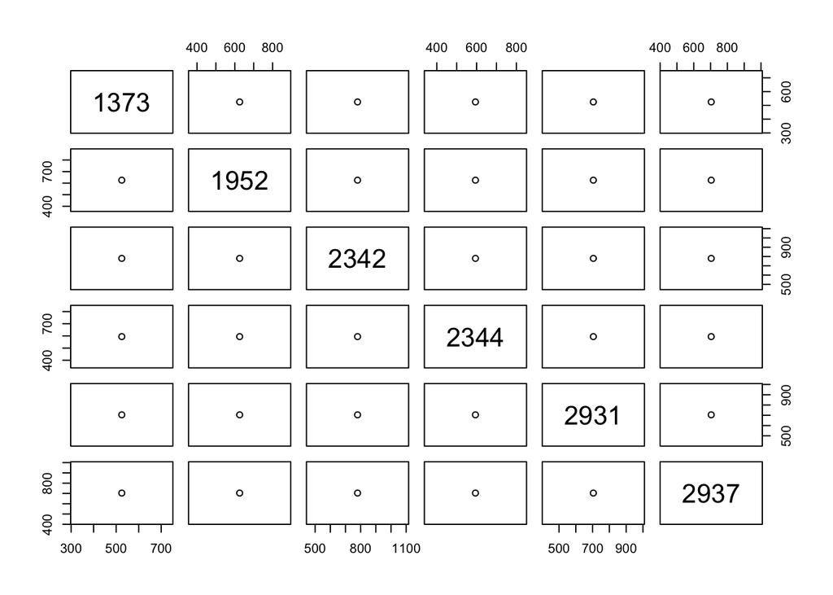

```r
shared_corr_kmers_1952_means <- colMeans(data_1952[,shared_corr_kmers])
shared_corr_kmers_2342_means <- colMeans(data_2342[,shared_corr_kmers])
shared_corr_kmers_2344_means <- colMeans(data_2344[,shared_corr_kmers])
shared_corr_kmers_2931_means <- colMeans(data_2931[,shared_corr_kmers])
shared_corr_kmers_2937_means <- colMeans(data_2937[,shared_corr_kmers])

shared_corr_kmers_df <- data.frame(shared_corr_kmers_1373_means, shared_corr_kmers_1952_means, shared_corr_kmers_2342_means, shared_corr_kmers_2344_means, shared_corr_kmers_2931_means, shared_corr_kmers_2937_means)
colnames(shared_corr_kmers_df) <- c("1373", "1952", "2342", "2344", "2931", "2937")

plot(shared_corr_kmers_df["AGGC",])
```

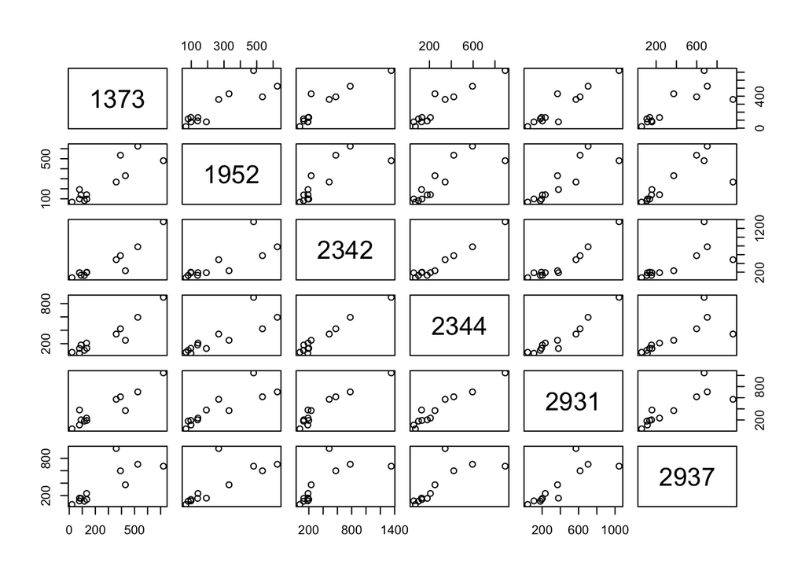

```r
plot(shared_corr_kmers_df)
```

```r
shared_corr_kmers_df
```

```
##             1373      1952       2342      2344       2931      2937
## AGGC   524.92308 625.71429  779.57143 594.26667  704.35714 703.86667
## AGGCGG 720.92308 480.78571 1352.71429 893.53333 1044.71429 672.80000
## ACGC   391.92308 534.92857  577.57143 422.46667  616.28571 598.46667
## ACGCC   78.15385  98.21429  185.78571  56.00000  110.07143 114.06667
## ACGCCC 116.15385  81.14286  126.28571  99.73333  180.21429 108.80000
## ACCGCC  21.00000  67.14286   74.21429  71.00000   41.14286  56.86667
## ACCCGC 132.92308 140.64286  188.85714 208.86667  234.42857 233.66667
## ACACGC 359.61538 267.42857  485.57143 343.60000  571.07143 957.26667
## ACAGGC  78.69231 192.42857  188.14286 127.46667  379.00000 158.66667
## ACAGGG 134.53846  97.35714  199.50000 130.80000  192.50000 136.53333
## ACCAGC  90.30769 138.57143  129.21429 179.73333  202.71429 154.66667
## AGGCGC 430.07692 330.71429  233.00000 250.40000  368.64286 373.60000
```

```r
shared_corr_kmers_corr <- cor(shared_corr_kmers_df)
shared_corr_kmers_corr
```

```
##           1373      1952      2342      2344      2931      2937
## 1373 1.0000000 0.8752619 0.9121997 0.9414233 0.9333322 0.8127379
## 1952 0.8752619 1.0000000 0.7929938 0.8432117 0.8637707 0.7735567
## 2342 0.9121997 0.7929938 1.0000000 0.9807948 0.9546691 0.7339158
## 2344 0.9414233 0.8432117 0.9807948 1.0000000 0.9622563 0.7610236
## 2931 0.9333322 0.8637707 0.9546691 0.9622563 1.0000000 0.8280011
## 2937 0.8127379 0.7735567 0.7339158 0.7610236 0.8280011 1.0000000
```

```r
# the means of these kmers are not the most correlated.
```